# CS 422 Section 02

## Random Forest

### 2.2-a

```r
library(randomForest)
set.seed(1122)
model <- randomForest(income ~ ., data=train, importance=TRUE)
pred <- predict(model, test, type="class")
confusionMatrix(pred, test[, 15])
```

```
Confusion Matrix and Statistics

          Reference
Prediction <=50K  >50K
     <=50K 11328  2711
     >50K     32   989

               Accuracy : 0.8179
                 95% CI : (0.8116, 0.824)
    No Information Rate : 0.7543
    P-Value [Acc > NIR] : < 2.2e-16

                  Kappa : 0.3499
 Mcnemar's Test P-Value : < 2.2e-16

            Sensitivity : 0.9972
            Specificity : 0.2673
         Pos Pred Value : 0.8069
         Neg Pred Value : 0.9687
             Prevalence : 0.7543
         Detection Rate : 0.7522
   Detection Prevalence : 0.9322
      Balanced Accuracy : 0.6322

       'Positive' Class : <=50K
```

1. The balanced accuracy is 0.632
2. The accuracy is 0.818
3. Sensitivity = 0.997, Specificity = 0.267

```r
summary(test)
```

```
      age                   workclass         fnlwgt               education    education_num                 marital_status
 Min.   :17.00   Private         :11021   Min.   :  13492   HS-grad     :4943   Min.   : 1.00   Divorced             :2083
 1st Qu.:28.00   Self-emp-not-inc: 1297   1st Qu.: 116655   Some-college:3221   1st Qu.: 9.00   Married-AF-spouse    :  11
 Median :37.00   Local-gov       : 1033   Median : 177955   Bachelors   :2526   Median :10.00   Married-civ-spouse   :6990
 Mean   :38.77   State-gov       :  667   Mean   : 189616   Masters     : 887   Mean   :10.11   Married-spouse-absent: 182
 3rd Qu.:48.00   Self-emp-inc    :  572   3rd Qu.: 238589   Assoc-voc   : 652   3rd Qu.:13.00   Never-married        :4872
 Max.   :90.00   Federal-gov     :  463   Max.   :1490400   11th        : 571   Max.   :16.00   Separated            : 472
                 (Other)         :    7                     (Other)     :2260                   Widowed              : 450
           occupation           relationship                  race           sex         capital_gain    capital_loss     hours_per_week
 Exec-managerial:1992   Husband       :6203   Amer-Indian-Eskimo:  149   Female: 4913   Min.   :    0   Min.   :   0.00   Min.   : 1.00
 Craft-repair   :1990   Not-in-family :3976   Asian-Pac-Islander:  408   Male  :10147   1st Qu.:    0   1st Qu.:   0.00   1st Qu.:40.00
 Prof-specialty :1970   Other-relative: 460   Black             : 1411                  Median :    0   Median :   0.00   Median :40.00
 Sales          :1824   Own-child     :2160   Other             :  122                  Mean   : 1120   Mean   :  89.04   Mean   :40.95
 Adm-clerical   :1819   Unmarried     :1576   White             :12970                  3rd Qu.:    0   3rd Qu.:   0.00   3rd Qu.:45.00
 Other-service  :1596   Wife          : 685                                             Max.   :99999   Max.   :3770.00   Max.   :99.00
 (Other)        :3869
       native_country    income
 United-States:13788   <=50K:11360
 Mexico       :  293   >50K : 3700
 Philippines  :   95
 Puerto-Rico  :   66
 Germany      :   65
 Canada       :   56
 (Other)      :  697
```

4. There 11360 positive class observations (<=50k) and 3700 negative class observations (>50K).
5. The sensitivity is so high because there are a lot of positive class observations to train on - the test data distribution doesn’t determine how the model deciedes whether something is positive or negative. But because there are a lot of positive observations to train on the model wrongly classified a bunch of false positives, lowering the specificity.

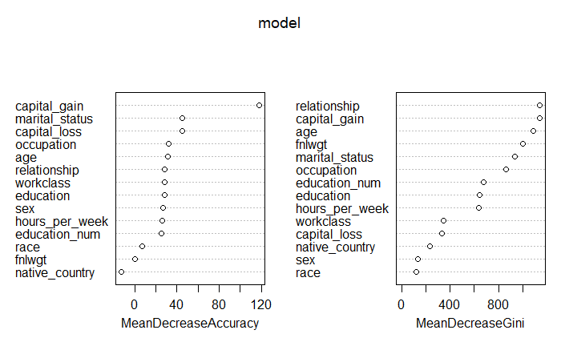

```r
varImpPlot(model)
```

6. For MeanDescreaseAccuracy, the most important variable is capital_gain because it gives us 120 accurate classifications. It seems that native_country actually helps classify less than 0 observations so it must be the least important.
7. For MeanDescreaseGini, the most important variable is relationship because splitting on relationship gives us the most information gain. Race is the least important because it gives us the least information gain - the gini index of the nodes after the split is close to the gini index before the split.

```r
print(model)
```

```
Call:
 randomForest(formula = income ~ ., data = train, importance = TRUE)
               Type of random forest: classification
                     Number of trees: 500
No. of variables tried at each split: 3

        OOB estimate of  error rate: 18.19%
Confusion matrix:
      <=50K >50K class.error
<=50K 22592   61   0.0026928
>50K   5424 2084   0.7224294
```

7. There are three variables tried at each split

### 2.2-b

```
mtry = 3  OOB error = 18.19%
Searching left ...
mtry = 2    OOB error = 17.78%
0.02242071 0.01
Searching right ...
mtry = 4    OOB error = 18.15%
-0.02088383 0.01
```

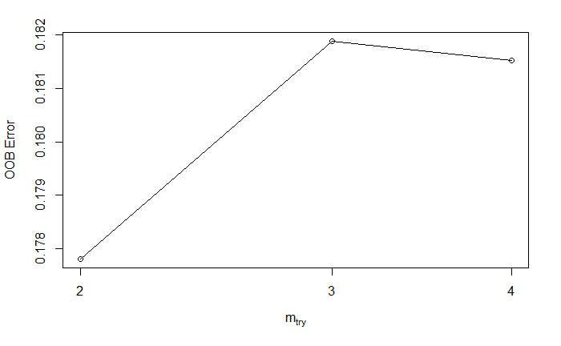

```r
set.seed(1122)
mtry <- tuneRF(train[, 1:14], train$income, ntreeTry=500, stepFactor=1.5,improve=0.01, trace=TRUE, plot=TRUE)
```

```r
print(mtry)
```

```
      mtry  OOBError
2.OOB    2 0.1778124
3.OOB    3 0.1818905
4.OOB    4 0.1815258
```

1. The default number of predictors was three
2. The optimal value of mtry suggested by the method was 2

```r
library(randomForest)
set.seed(1122)
model <- randomForest(income ~ ., data=train, importance=TRUE, mtry=2)
pred <- predict(model, test, type="class")
confusionMatrix(pred, test[, 15])
```

```
Confusion Matrix and Statistics

          Reference
Prediction <=50K  >50K
     <=50K 11326  2667
     >50K     34  1033

               Accuracy : 0.8207
                 95% CI : (0.8144, 0.8267)
    No Information Rate : 0.7543
    P-Value [Acc > NIR] : < 2.2e-16

                  Kappa : 0.3634
 Mcnemar's Test P-Value : < 2.2e-16

            Sensitivity : 0.9970
            Specificity : 0.2792
         Pos Pred Value : 0.8094
         Neg Pred Value : 0.9681
             Prevalence : 0.7543
         Detection Rate : 0.7521
   Detection Prevalence : 0.9292
      Balanced Accuracy : 0.6381

       'Positive' Class : <=50K
```

1. The balanced accuracy is 0.638
2. The accuracy of the model is 0.821
3. Sensitivity = 0.997, Specificity = 0.280

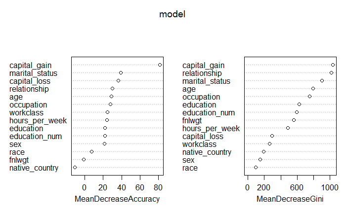

```r
varImpPlot(model)
```

## Association Rules

### 2.3-i

```r
library(arules)
trans <- read.transactions("groceries.csv")
```

```
removing duplicated items in transactions
```

```r
rules <- apriori(trans)
```

```
Apriori

Parameter specification:
 confidence minval smax arem  aval originalSupport maxtime support minlen maxlen target   ext
        0.8    0.1    1 none FALSE            TRUE       5     0.1      1     10  rules FALSE

Algorithmic control:
 filter tree heap memopt load sort verbose
    0.1 TRUE TRUE  FALSE TRUE    2    TRUE

Absolute minimum support count: 983

set item appearances ...[0 item(s)] done [0.01s].
set transactions ...[6928 item(s), 9835 transaction(s)] done [0.02s].
sorting and recoding items ... [0 item(s)] done [0.00s].
creating transaction tree ... done [0.00s].
checking subsets of size 1 done [0.00s].
writing ... [0 rule(s)] done [0.01s].
creating S4 object  ... done [0.01s].
```

1. The original apriori() method gave me 0 rules

```r
rules <- apriori(trans, parameter = list(supp=0.0006))
```

```
Apriori

Parameter specification:
 confidence minval smax arem  aval originalSupport maxtime support minlen maxlen target   ext
        0.8    0.1    1 none FALSE            TRUE       5   6e-04      1     10  rules FALSE

Algorithmic control:
 filter tree heap memopt load sort verbose
    0.1 TRUE TRUE  FALSE TRUE    2    TRUE

Absolute minimum support count: 5

set item appearances ...[0 item(s)] done [0.01s].
set transactions ...[6928 item(s), 9835 transaction(s)] done [0.03s].
sorting and recoding items ... [753 item(s)] done [0.01s].
creating transaction tree ... done [0.00s].
checking subsets of size 1 2 3 4 5 done [0.03s].
writing ... [485 rule(s)] done [0.01s].
creating S4 object  ... done [0.01s].
```

2. With a minsup of 0.0006 I can get 485 rules, 0.0007 gives me a little less than 400

### 2.3-iii

```r
summary(trans)
```

```
transactions as itemMatrix in sparse format with
 9835 rows (elements/itemsets/transactions) and
 6928 columns (items) and a density of 0.0005240481

most frequent items:
            bags vegetables,whole             beer            whole         tropical          (Other)
             971              940              829              717              482            31768

element (itemset/transaction) length distribution:
sizes
   1    2    3    4    5    6    7    8    9   10   11   12   13   14   15   16   17   18   19   20   21   23
1380 2743 1782 1246  907  599  413  294  166   94   76   43   39   20   10    9    2    3    3    3    1    2

   Min. 1st Qu.  Median    Mean 3rd Qu.    Max.
  1.000   2.000   3.000   3.631   5.000  23.000

includes extended item information - examples:
                labels
1          (appetizer)
2 (appetizer),bathroom
3     (appetizer),cake
```

3. I don’t believe that the most frequently bought item is “bags vegetables,” so it must just be “bags” with a count of 971

### 2.3-iv

```r
frequencies <- itemFrequency(trans, type="absolute")
frequencies <- sort(frequencies, decreasing = FALSE)
```

4. The least frequent item is artif at 1 purchase.

### 2.3-v

```r
rules <- sort(rules, decreasing = TRUE, na.last = NA, by = "support")
inspect(rules[1:5])
```

```
    lhs          rhs      support    confidence lift     count
[1] {bakery}  => {life}   0.03741739 1.0000000  26.72554 368
[2] {life}    => {bakery} 0.03741739 1.0000000  26.72554 368
[3] {canned}  => {beer}   0.02653787 0.8080495   9.58645 261
[4] {product} => {bakery} 0.01321810 1.0000000  26.72554 130
[5] {product} => {life}   0.01321810 1.0000000  26.72554 130
```

### 2.3-vi

```r
rules <- sort(rules, decreasing = TRUE, na.last = NA, by = "confidence")
inspect(rules[1:5])
```

```
    lhs                 rhs      support    confidence lift     count
[1] {bakery}         => {life}   0.03741739 1          26.72554 368
[2] {life}           => {bakery} 0.03741739 1          26.72554 368
[3] {product}        => {bakery} 0.01321810 1          26.72554 130
[4] {product}        => {life}   0.01321810 1          26.72554 130
[5] {bakery,product} => {life}   0.01321810 1          26.72554 130
```

### 2.3-vii

```r
rules <- sort(rules, decreasing = FALSE, na.last = NA, by = "support")
inspect(rules[1:5])
```

```
    lhs                  rhs       support      confidence lift      count
[1] {coffee,shopping} => {bags}    0.0006100661 1           10.12873 6
[2] {milk,shopping}   => {bags}    0.0006100661 1           10.12873 6
[3] {vegetables,pot}  => {plants}  0.0006100661 1           65.13245 6
[4] {beer,flower}     => {(seeds)} 0.0006100661 1          108.07692 6
[5] {Instant}         => {food}    0.0006100661 1           74.50758 6
```

### 2.3-viii

```r
rules <- sort(rules, decreasing = FALSE, na.last = NA, by = "confidence")
inspect(rules[1:5])
```

```
    lhs                                       rhs                support      confidence lift       count
[1] {eggs,brown,fruit,root}                => {vegetables,whole} 0.0008134215 0.8          8.370213  8
[2] {beer,water,fruit/vegetable}           => {juice,bottled}    0.0008134215 0.8        115.705882  8
[3] {cheese,cream,vegetables,other}        => {fruit,root}       0.0008134215 0.8         22.480000  8
[4] {cheese,cheese,cream,vegetables,other} => {fruit,root}       0.0008134215 0.8         22.480000  8
[5] {cheese,fruit,root,vegetables,whole}   => {vegetables,other} 0.0012201322 0.8         20.870027 12
```